# flexiSDM

2026 TWS

2026-11-03

# 1 Introduction

This vignette walks you through fitting an **integrated species distribution model (iSDM)** using the `SpFut.flexiSDM` package. We work with a fictional species—the **Great Salt Lake Cyclops**—to demonstrate how to integrate multiple datasets into a single model.

## 1.1 Learning objectives

By the end of this workshop you will be able to:

1. Define a study region with associated environmental covariates
2. Set up and fit an integrated SDM in NIMBLE via `SpFut.flexiSDM`
3. Summarize and visualize model output
4. Compare model estimates against known truth

# 2 Prerequisites

Confirm that you have the correct package version installed. This package is stored on GitLab, NOT CRAN, so you need to use `remotes::install_git()` rather than `install.packages()`.

```r
remotes::install_git("https://code.usgs.gov/eastern-ecological-science-center/nearmi/SpFut-flexiSDM.git", force = T)

packageVersion("SpFut.flexiSDM") == "1.1.3"
```

Load the packages used throughout and set a seed for reproducibility.

```r
library(tidyverse)
library(SpFut.flexiSDM)

set.seed(1)
```

# 3 Understanding the inputs

We begin from pre-built data. The section `Simulate data` at the end of this tutorial demonstrates how to simulate the data.

```r
load("TWS2026/data/data.RData", verbose = TRUE)
```

```
#> Loading objects:
#>   region
#>   datalist
#>   species.data
#>   covar
#>   true
```

## 3.1 The region

A `region` object has four components. It can be created by `make_region()` (real species) or `format_sim()` (simulated species).

| Component | What it is |
| --- | --- |
| `range` | Boundary used to build the study region (`NULL` for simulated range) |
| `region` | Outer boundary of the study region |
| `sp.grid` | Spatial analysis units (here, 25 km² hexbins) |
| `boundary` | Where the region is cut off (can differ from `region`) |

```r
# For a simulated species, range is NULL
region$range
```

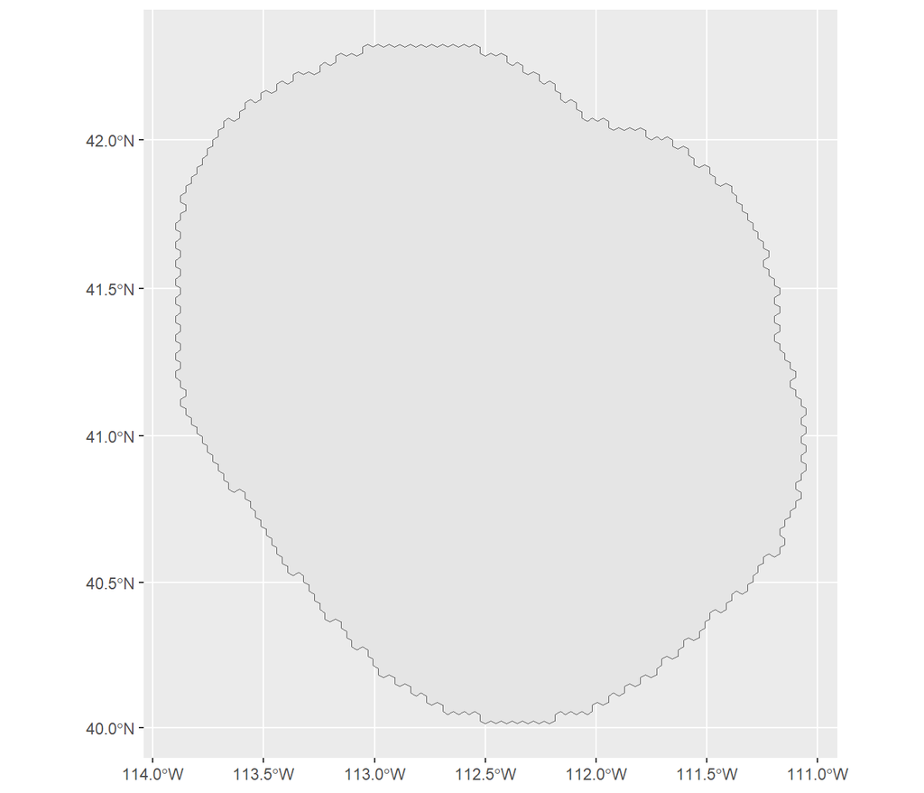

```r
# Outer boundary of the study region
ggplot(region$region) + geom_sf()
```

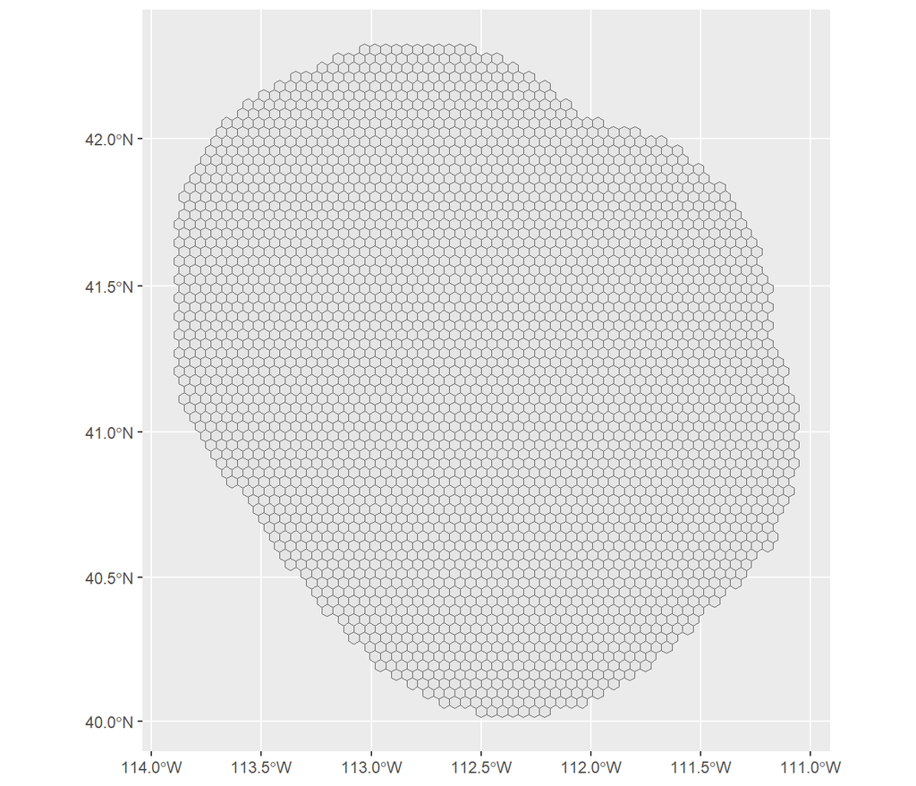

```r
# sp.grid holds the spatial units for analysis (25 km2 hexbins)
ggplot(region$sp.grid) + geom_sf()
```

```r
nrow(region$sp.grid)
```

```
#> [1] 3213
```

```r
# conus.grid.id is a unique label for each hexbin
head(region$sp.grid)
```

|  | conus.grid.id | geometry |
| --- | --- | --- |
| 1 | 134 |  |
| 2 | 135 |  |
| 3 | 136 |  |
| 4 | 137 |  |
| 5 | 138 |  |
| 6 | 139 |  |

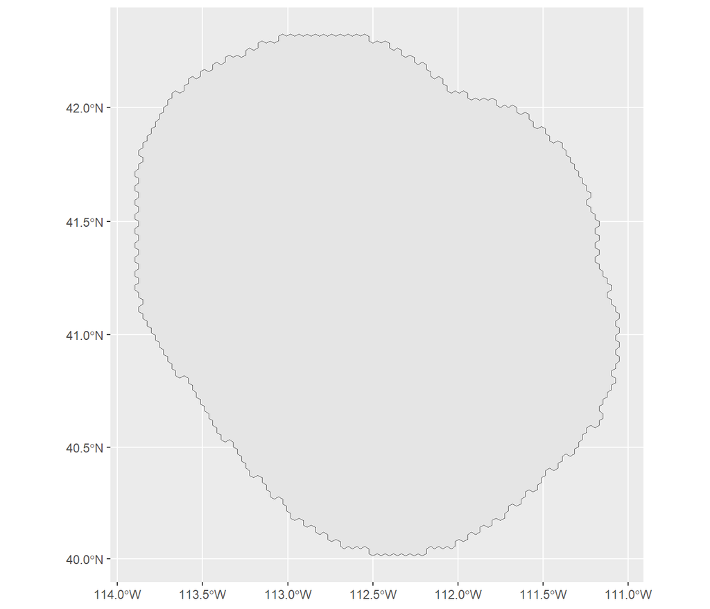

```r
# boundary dictates where the region is cut off
# (here identical to region, but it could be e.g. a state boundary)
ggplot(region$boundary) + geom_sf()
```

> **Note.** `conus.grid.id` is the key that links every dataset, covariate, and output back to a specific hexbin.

## 3.2 Species data

The `species.data` object (from `load_species_data()` or `format_sim()`) has two elements:

- **`locs`** — where each data point sits in discrete (`disc`, assigned to a hexbin) and continuous (`cont`, coordinates) space. This is useful for mapping.
- **`obs`** — a list where each element holds date, location, and count info for one dataset.

```r
head(species.data$locs$disc)
```

|  | site.id | survey.id | pass.id | conus.grid.id | year | source |
| --- | --- | --- | --- | --- | --- | --- |
| 1 | 1 | 1-1 | 1 | 2974 | 2026 | iNat |
| 2 | 2 | 2-2 | 1 | 2975 | 2026 | iNat |
| 3 | 3 | 3-3 | 1 | 2983 | 2026 | iNat |
| 4 | 4 | 4-4 | 1 | 2984 | 2026 | iNat |
| 5 | 5 | 5-5 | 1 | 2987 | 2026 | iNat |
| 6 | 6 | 6-6 | 1 | 2988 | 2026 | iNat |

```r
head(species.data$locs$cont)
```

|  | site.id | survey.id | pass.id | survey.conducted | day | month | year | data.type | source | geometry |
| --- | --- | --- | --- | --- | --- | --- | --- | --- | --- | --- |
| 1 | 1 | 1-1 | 1 | 1 | 3 | 11 | 3 | PO | iNat |  |
| 2 | 2 | 2-2 | 1 | 1 | 3 | 11 | 3 | PO | iNat |  |
| 3 | 3 | 3-3 | 1 | 1 | 3 | 11 | 3 | PO | iNat |  |
| 4 | 4 | 4-4 | 1 | 1 | 3 | 11 | 3 | PO | iNat |  |
| 5 | 5 | 5-5 | 1 | 1 | 3 | 11 | 3 | PO | iNat |  |
| 6 | 6 | 6-6 | 1 | 1 | 3 | 11 | 3 | PO | iNat |  |

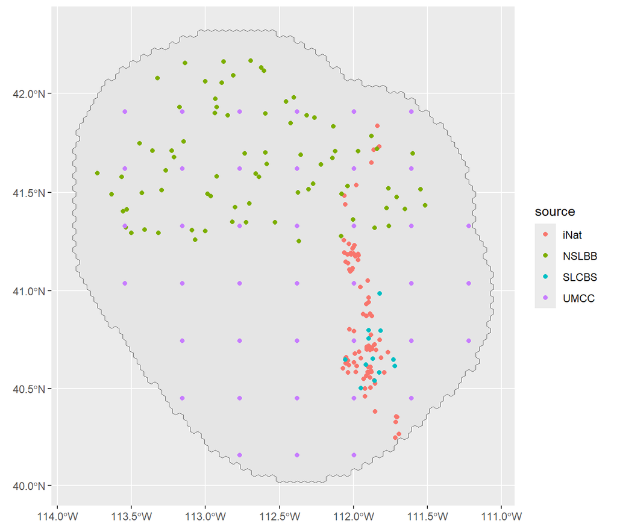

```r
# Overlay observation locations on the region, colored by source
ggplot() +
  geom_sf(data = region$region) +
  geom_sf(data = species.data$locs$cont, aes(color = source))
```

```r
# Peek at each dataset
head(species.data$obs$iNat)   # presence-only
```

|  | source | data.type | site.id | conus.grid.id | survey.id | pass.id | day | month | year | lat | lon | survey.conducted | species | age | time.to.detect | individual.id | count |
| --- | --- | --- | --- | --- | --- | --- | --- | --- | --- | --- | --- | --- | --- | --- | --- | --- | --- |
| 1 | iNat | PO | 1 | 2974 | 1-1 | 1 | 3 | 11 | 3 | NA | NA | 1 | sim | NR | NA | NA | 1 |
| 2 | iNat | PO | 2 | 2975 | 2-2 | 1 | 3 | 11 | 3 | NA | NA | 1 | sim | NR | NA | NA | 1 |
| 3 | iNat | PO | 3 | 2983 | 3-3 | 1 | 3 | 11 | 3 | NA | NA | 1 | sim | NR | NA | NA | 1 |
| 4 | iNat | PO | 4 | 2984 | 4-4 | 1 | 3 | 11 | 3 | NA | NA | 1 | sim | NR | NA | NA | 1 |
| 5 | iNat | PO | 5 | 2987 | 5-5 | 1 | 3 | 11 | 3 | NA | NA | 1 | sim | NR | NA | NA | 1 |
| 6 | iNat | PO | 6 | 2988 | 6-6 | 1 | 3 | 11 | 3 | NA | NA | 1 | sim | NR | NA | NA | 1 |

```r
head(species.data$obs$NSLBB)  # detection / non-detection
```

|  | source | data.type | site.id | conus.grid.id | survey.id | pass.id | day | month | year | lat | lon | survey.conducted | species | age | time.to.detect | individual.id | count | cov.siteA |
| --- | --- | --- | --- | --- | --- | --- | --- | --- | --- | --- | --- | --- | --- | --- | --- | --- | --- | --- |
| 1 | NSLBB | DND | 1 | 368 | 1-1 | 1 | 3 | 11 | 3 | NA | NA | 1 | sim | NR | NA | NA | 1 | -0.6592884 |
| 2 | NSLBB | DND | 2 | 556 | 2-1 | 1 | 3 | 11 | 3 | NA | NA | 1 | sim | NR | NA | NA | 0 | -1.6234926 |
| 3 | NSLBB | DND | 3 | 596 | 3-1 | 1 | 3 | 11 | 3 | NA | NA | 1 | sim | NR | NA | NA | 1 | -0.8294119 |
| 4 | NSLBB | DND | 4 | 668 | 4-1 | 1 | 3 | 11 | 3 | NA | NA | 1 | sim | NR | NA | NA | 1 | -0.6237285 |
| 5 | NSLBB | DND | 5 | 669 | 5-1 | 1 | 3 | 11 | 3 | NA | NA | 1 | sim | NR | NA | NA | 1 | -1.2849953 |
| 6 | NSLBB | DND | 6 | 669 | 6-1 | 1 | 3 | 11 | 3 | NA | NA | 1 | sim | NR | NA | NA | 1 | 0.3723328 |

```r
head(species.data$obs$UMCC)   # count
```

|  | source | data.type | site.id | conus.grid.id | survey.id | pass.id | day | month | year | lat | lon | survey.conducted | species | age | time.to.detect | individual.id | count | cov.siteA |
| --- | --- | --- | --- | --- | --- | --- | --- | --- | --- | --- | --- | --- | --- | --- | --- | --- | --- | --- |
| 1 | UMCC | count | 1 | 634 | 1-1 | 1 | 3 | 11 | 3 | NA | NA | 1 | sim | NR | NA | NA | 1 | -1.8556780 |
| 2 | UMCC | count | 2 | 663 | 2-1 | 1 | 3 | 11 | 3 | NA | NA | 1 | sim | NR | NA | NA | 4 | 0.6272162 |
| 3 | UMCC | count | 3 | 668 | 3-1 | 1 | 3 | 11 | 3 | NA | NA | 1 | sim | NR | NA | NA | 3 | -1.6969726 |
| 4 | UMCC | count | 4 | 677 | 4-1 | 1 | 3 | 11 | 3 | NA | NA | 1 | sim | NR | NA | NA | 4 | 0.3019304 |
| 5 | UMCC | count | 5 | 1228 | 5-1 | 1 | 3 | 11 | 3 | NA | NA | 1 | sim | NR | NA | NA | 6 | 1.0367969 |
| 6 | UMCC | count | 6 | 1242 | 6-1 | 1 | 3 | 11 | 3 | NA | NA | 1 | sim | NR | NA | NA | 2 | -1.0715095 |

```r
head(species.data$obs$SLCBS)  # count, repeated visits
```

|  | source | data.type | site.id | conus.grid.id | survey.id | pass.id | day | month | year | lat | lon | survey.conducted | species | age | time.to.detect | individual.id | count | intercept | cov.siteA |
| --- | --- | --- | --- | --- | --- | --- | --- | --- | --- | --- | --- | --- | --- | --- | --- | --- | --- | --- | --- |
| 1 | SLCBS | count | 1 | 3013 | 1-1 | 1 | 3 | 11 | 3 | NA | NA | 1 | sim | NR | NA | NA | 0 | 1 | 0.6886489 |
| 2 | SLCBS | count | 1 | 3013 | 1-10 | 1 | 3 | 11 | 3 | NA | NA | 1 | sim | NR | NA | NA | 0 | 1 | 0.6886489 |
| 3 | SLCBS | count | 1 | 3013 | 1-2 | 1 | 3 | 11 | 3 | NA | NA | 1 | sim | NR | NA | NA | 0 | 1 | 0.6886489 |
| 4 | SLCBS | count | 1 | 3013 | 1-3 | 1 | 3 | 11 | 3 | NA | NA | 1 | sim | NR | NA | NA | 0 | 1 | 0.6886489 |
| 5 | SLCBS | count | 1 | 3013 | 1-4 | 1 | 3 | 11 | 3 | NA | NA | 1 | sim | NR | NA | NA | 0 | 1 | 0.6886489 |
| 6 | SLCBS | count | 1 | 3013 | 1-5 | 1 | 3 | 11 | 3 | NA | NA | 1 | sim | NR | NA | NA | 0 | 1 | 0.6886489 |

Visualize everything together with `map_species_data()`.

```
#> Using real map features
```

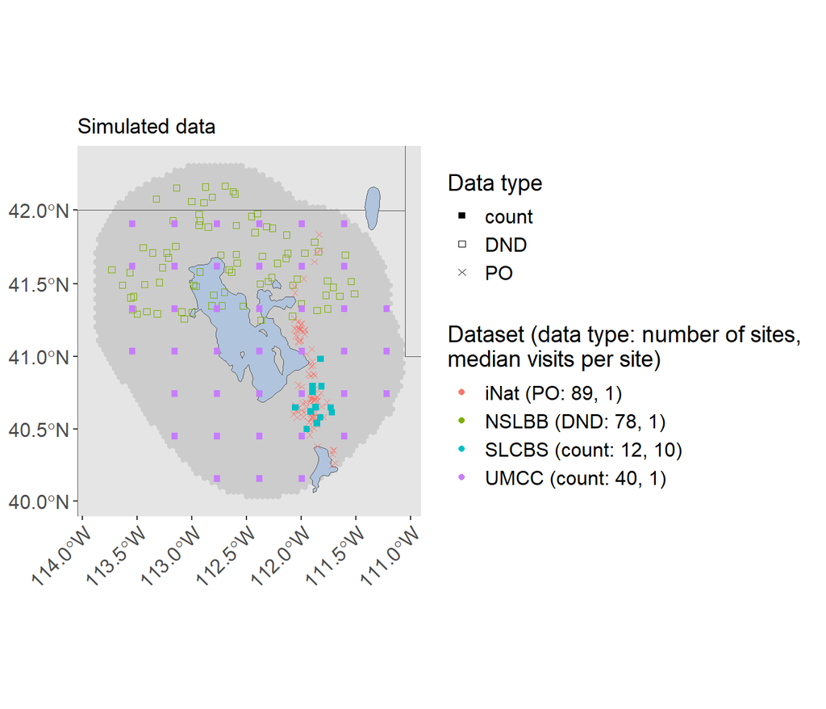

```r
map_species_data(title = "Simulated data",
                 region = region,
                 plot = "samples",
                 sim = TRUE,
                 details = TRUE,
                 species.data = species.data,
                 inat.agg = FALSE,
                 plot.range = FALSE,
                 plot.region = TRUE,
                 subtitle = FALSE,
                 out = NULL)$plot
```

## 3.3 Covariates

Environmental covariates live in a data frame (`covar`) with `conus.grid.id` that matches `region$sp.grid`. Values must already be **scaled**, and quadratic terms must be **pre-squared**.

```r
# Linear + quadratic covariates for the ecological process
covs.z  <- c("wetland", "footprint", "S", "elevation", "elevation2")

# Covariates for the presence-only (iNat) observation process.
# Because PO data are modeled at the hexbin level, these must also live in covar.
covs.PO <- c("effort")


head(covar)
```

| conus.grid.id | wetland | footprint | elevation | elevation2 | S | effort |
| --- | --- | --- | --- | --- | --- | --- |
| 1000 | -0.2445427 | 0.2477448 | -0.9051147 | 0.8192326 | -0.1592007 | -0.03309897 |
| 1001 | -0.2445427 | -0.5920820 | -0.9070393 | 0.8227204 | -0.4352460 | -0.35216592 |
| 1002 | -0.2445427 | -0.6898884 | -0.9128735 | 0.8333380 | -0.2972233 | -0.67955136 |
| 1003 | -0.2445427 | -0.6815503 | -0.9180184 | 0.8427578 | -0.4352460 | -0.63462802 |
| 1004 | -0.2445427 | -0.7407239 | -0.9067180 | 0.8221375 | 0.1858559 | -1.13777661 |
| 1005 | -0.2445427 | -0.7407239 | -0.9200688 | 0.8465265 | -0.7112913 | -0.65073480 |

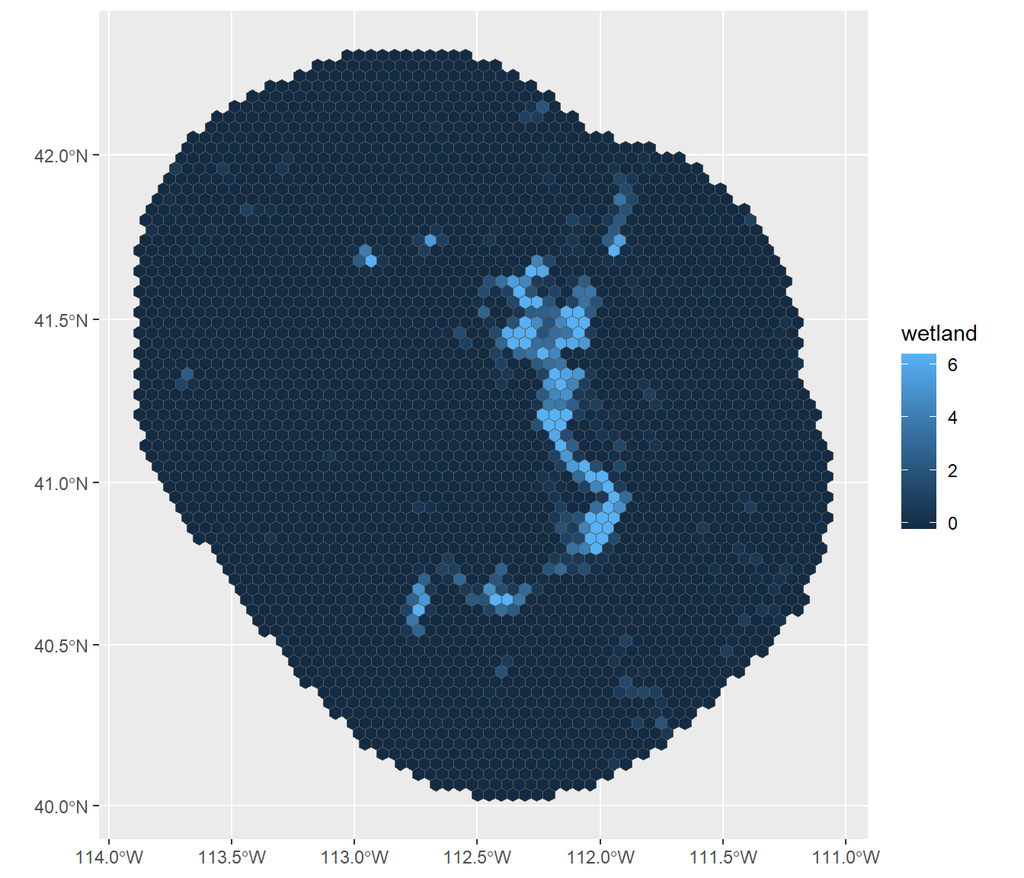

```r
gridcovar <- full_join(region$sp.grid, covar, by = "conus.grid.id")

ggplot(gridcovar) + geom_sf(aes(fill = wetland))
```

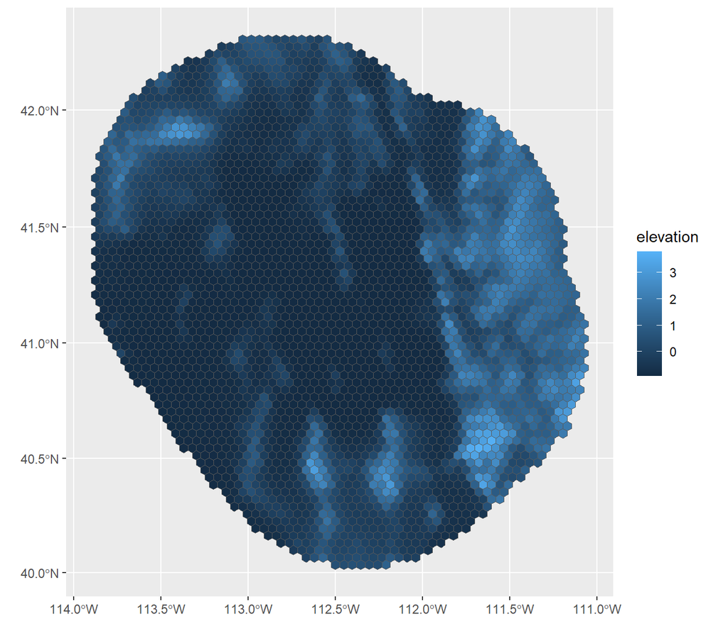

```r
ggplot(gridcovar) + geom_sf(aes(fill = elevation))
```

Attach labels, then plot the covariates and check correlations.

```r
cov.labs <- data.frame(
  covariate = names(covar),
  Label = c("conus.grid.id", "Wetland", "Footprint", "Elevation",
            "Elevation^2", "South", "Effort")) %>%
  filter(covariate != "conus.grid.id")

cov.labs
```

| covariate | Label |
| --- | --- |
| wetland | Wetland |
| footprint | Footprint |
| elevation | Elevation |
| elevation2 | Elevation^2 |
| S | South |
| effort | Effort |

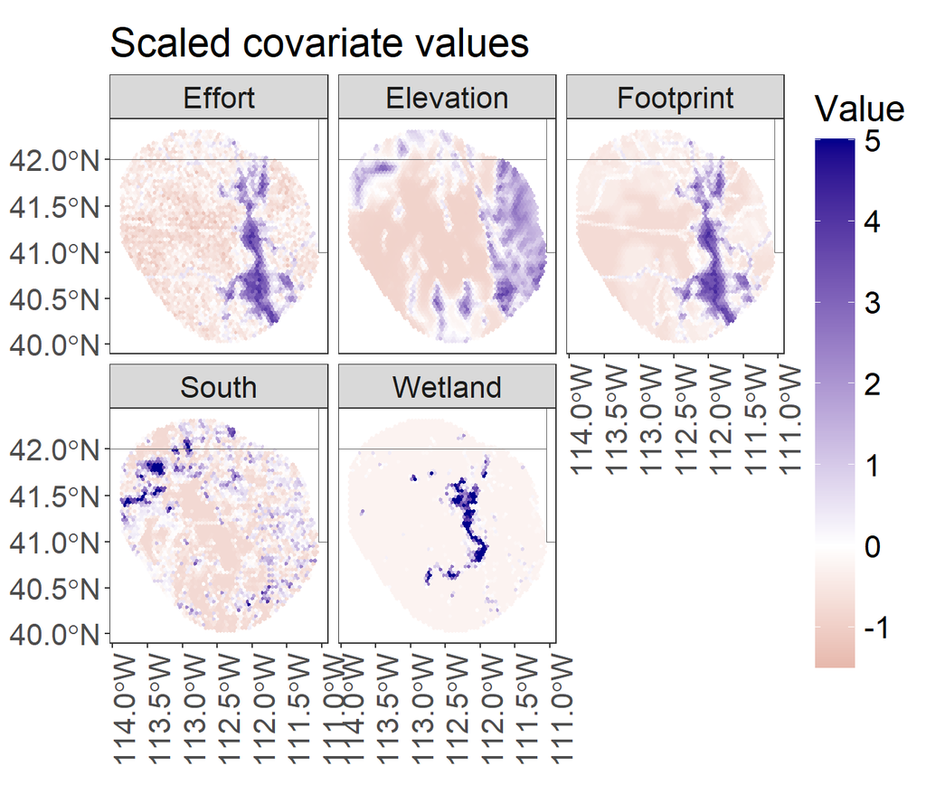

```r
plot_covar(covar = covar,
           region = region,
           cov.labs = cov.labs,
           scaled = TRUE)$plot
```

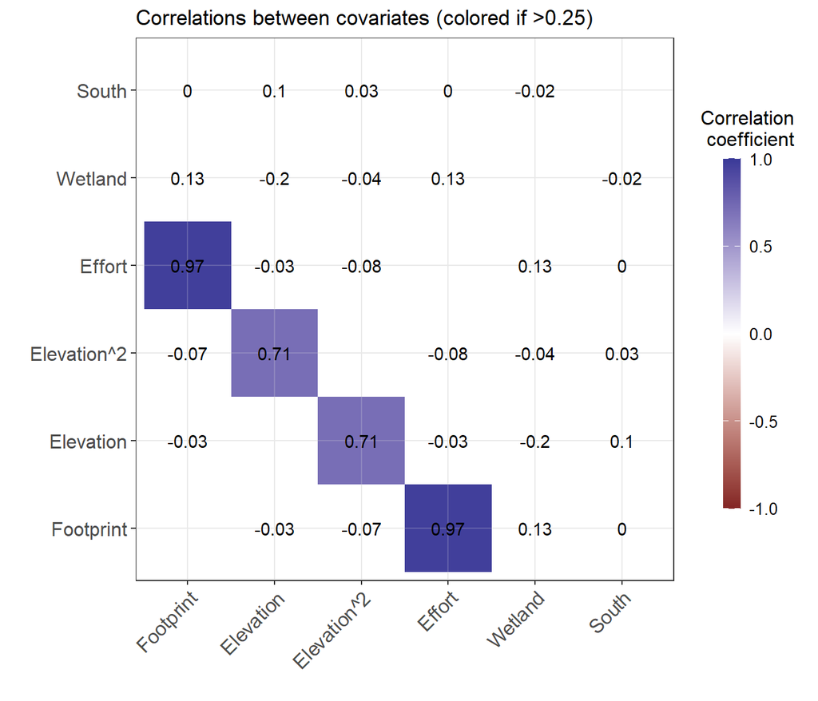

```r
cor_covar(covar = covar,
          cov.labs = cov.labs,
          color.threshold = 0.25)$plot
```

> **Checkpoint.** Highly correlated covariates (flagged by `cor_covar()`) can destabilize estimates. Inspect the correlation plot before proceeding.

# 4 Setting up model components

## 4.1 The gridkey and cross-validation

The `gridkey` maps hexbins to NIMBLE indices and assigns each to a `"test"` or `"train"` group. We first generate spatial blocks for cross-validation.

```r
# k = number of folds the blocks are grouped into
spatblocks <- make_CV_blocks(region, rows = 5, cols = 5, k = 3)

head(spatblocks)
```

|  | id | block_id | folds | geometry |
| --- | --- | --- | --- | --- |
| 2 | 2 | 1 | 2 |  |
| 3 | 3 | 2 | 3 |  |
| 4 | 4 | 3 | 1 |  |
| 5 | 5 | 4 | 2 |  |
| 6 | 6 | 5 | 3 |  |
| 7 | 7 | 6 | 1 |  |

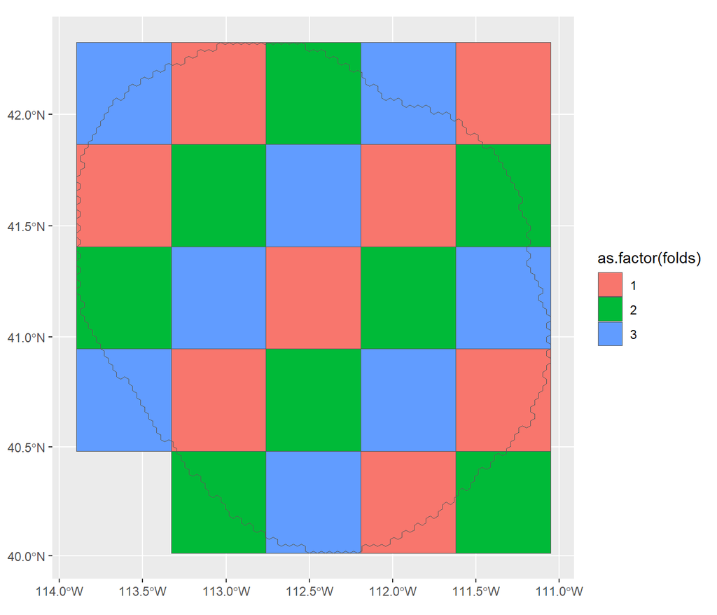

```r
ggplot() +
  geom_sf(data = spatblocks, aes(fill = as.factor(folds))) +
  geom_sf(data = region$region, fill = NA)
```

Choose which fold to hold out. `"none"` uses all data for training.

```r
fold.out <- "none"
gridkey  <- make_gridkey(region, spatblocks, fold.out = fold.out)

head(gridkey)
```

|  | conus.grid.id | grid.id | group |
| --- | --- | --- | --- |
| 1 | 134 | 1 | train |
| 2 | 135 | 2 | train |
| 3 | 136 | 3 | train |
| 4 | 137 | 4 | train |
| 5 | 138 | 5 | train |
| 6 | 139 | 6 | train |

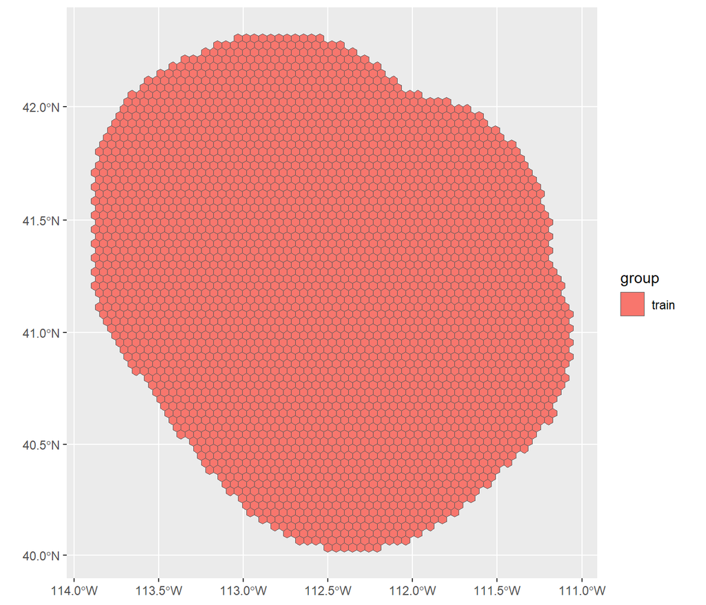

```r
# Visualize the train/test split
key <- full_join(region$sp.grid, gridkey, by = "conus.grid.id")
ggplot() + geom_sf(data = key, aes(fill = group))
```

> **Try it.** Set `fold.out = 1` and re-plot. The cells in fold 1 become test data; to evaluate predictive performance, you could predict intensity in these cells and then compare the predicted values to the truth.

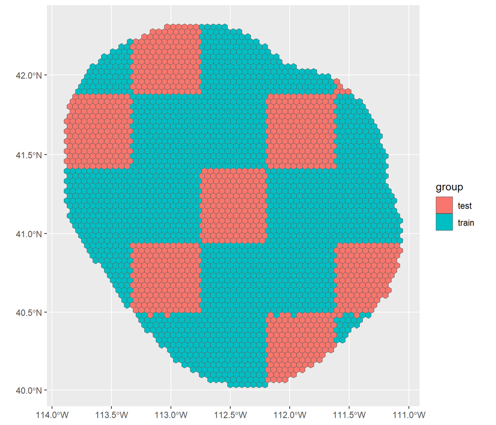

```r
gridkey1 <- make_gridkey(region, spatblocks, fold.out = 1, method = "overlap")

key1 <- full_join(region$sp.grid, gridkey1, by = "conus.grid.id")
ggplot() + geom_sf(data = key1, aes(fill = group))
```

## 4.2 Spatial random effect

The ICAR spatial random effect can be estimated on a **coarse grid** to cut runtime: rather than one random effect per hexbin, effects are estimated per group of hexbins.

```r
spatRegion <- suppressWarnings(make_spatkey(region$sp.grid))

# spatkey maps each conus.grid.id to a spat.grid.id
spatRegion$spatkey[1:10,]
```

| spat.grid.id | conus.grid.id |
| --- | --- |
| 1 | 134 |
| 1 | 135 |
| 1 | 172 |
| 1 | 210 |
| 1 | 211 |
| 1 | 248 |
| 2 | 136 |
| 2 | 173 |
| 2 | 174 |
| 2 | 212 |

```r
# spatgrid is an sf object containing the coarse grid
head(spatRegion$spat.grid)
```

| geometry | spat.grid.id |
| --- | --- |
|  | 1 |
|  | 2 |
|  | 3 |
|  | 4 |
|  | 5 |
|  | 6 |

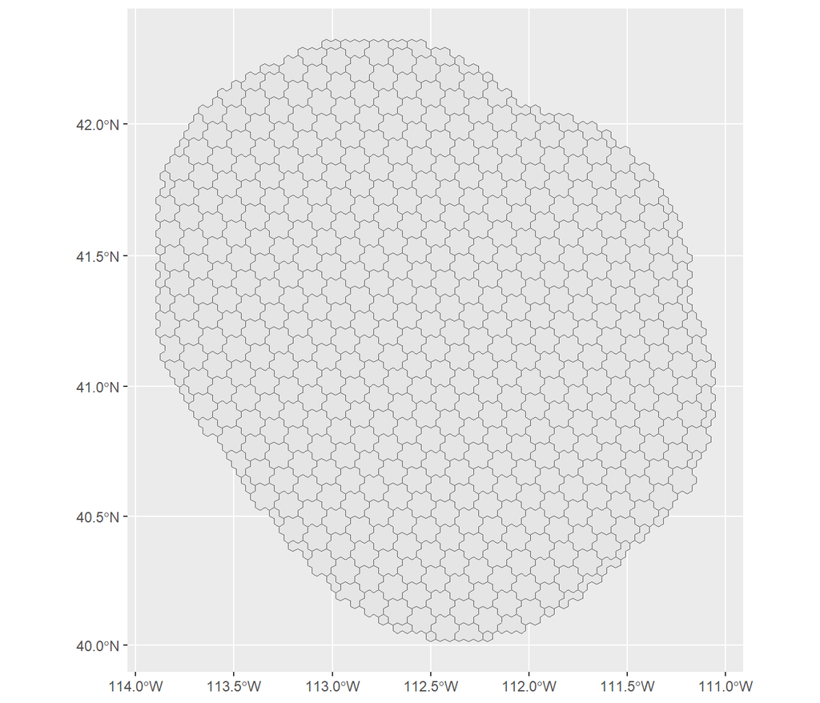

```r
ggplot(spatRegion$spat.grid) + geom_sf()
```

For this vignette we estimate without the coarse grid, so set spatRegion to `NULL`.

```r
spatRegion <- NULL
```

# 5 Building the NIMBLE model

## 5.1 Describe your datasets with file.info

Each dataset needs a row describing its type and detection covariates.

| Field | Meaning |
| --- | --- |
| `file.label` | Must match `names(species.data$obs)` |
| `data.type` | `"PO"`, `"DND"`, or `"count"` |
| `covar.mean` | Detection covariate(s) averaged across passes |
| `covar.sum` | Detection covariate(s) summed across passes |
| `PO.extent` | `"CONUS"` or a two-letter state code (`NA` for non-PO) |

```r
file.info <- data.frame(file.label = c("iNat", "NSLBB", "UMCC", "SLCBS"),
                        data.type  = c("PO",   "DND",   "count", "count"),
                        covar.mean = c("effort", "cov.siteA", "cov.siteA", "cov.siteA"),
                        covar.sum  = c(NA, NA, NA, NA),
                        PO.extent  = c("CONUS", NA, NA, NA))

file.info
```

| file.label | data.type | covar.mean | covar.sum | PO.extent |
| --- | --- | --- | --- | --- |
| iNat | PO | effort | NA | CONUS |
| NSLBB | DND | cov.siteA | NA | NA |
| UMCC | count | cov.siteA | NA | NA |
| SLCBS | count | cov.siteA | NA | NA |

## 5.2 Format species data for NIMBLE

The species data are formatted into `data` and `constants`, which eventually go into NIMBLE.

```r
sp.data <- sppdata_for_nimble(species.data = species.data,
                              region = region,
                              covar = covar,

                              # things defined earlier
                              file.info = file.info,
                              covs.PO = covs.PO,
                              keep.conus.grid.id = gridkey$conus.grid.id[gridkey$group == "train"],

                              # which observation models to use
                              occ.mod = TRUE,
                              nmix.mod = TRUE,
                              min.visits.incl = 3,

                              # these options only apply to real data; see the companion vignette
                              stategrid = NULL,
                              statelines.rm = FALSE)
```

```
#> No iNaturalist data for this species
#>
#> Loading PO, dataset 1
#> Loading DND, dataset 2
#> Using age classes:  NR
#> Loading count, dataset 3
#> Using age classes:  NR
#> Loading count, dataset 4
#> Using age classes:  NR
```

```r
# One formatted element per dataset
names(sp.data)
```

```
#> [1] "PO1"    "DND2"   "count3" "count4"
```

```r
lapply(sp.data$PO1$data, head)
```

```
#> $Xw1
#> # A tibble: 6 × 1
#>   effort
#>    <dbl>
#> 1 -0.479
#> 2 -0.738
#> 3 -0.517
#> 4 -0.408
#> 5 -0.530
#> 6 -0.564
#>
#> $W1
#> [1] 0 0 0 0 0 0
#>
#> $area1
#> [1] 1 1 1 1 1 1
```

```r
lapply(sp.data$PO1$constants, head)
```

```
#> $nCovW1
#> [1] 1
#>
#> $Wcells1
#> [1] "134" "135" "136" "137" "138" "139"
#>
#> $nW1
#> [1] 3213
#>
#> $name1
#> [1] "iNat"
```

```r
lapply(sp.data$DND2$data, head)
```

```
#> $Xv2
#> # A tibble: 6 × 1
#>   cov.siteA
#>       <dbl>
#> 1    -0.654
#> 2    -1.88
#> 3    -0.871
#> 4    -0.609
#> 5    -1.45
#> 6     0.661
#>
#> $V2
#> [1] 1 0 1 1 1 1
#>
#> $area2
#> [1] 1 1 1 1 1 1
```

```r
lapply(sp.data$count3$data, head)
```

```
#> $Xy3
#> # A tibble: 6 × 1
#>   cov.siteA
#>       <dbl>
#> 1    -1.66
#> 2     0.714
#> 3    -1.51
#> 4     0.403
#> 5     1.11
#> 6    -0.909
#>
#> $Y3
#> [1] 1 4 3 4 6 2
#>
#> $area3
#> [1] 1 1 1 1 1 1
```

```r
lapply(sp.data$count4$data, head)
```

```
#> $Xy4
#> # A tibble: 6 × 2
#>   intercept cov.siteA
#>       <dbl>     <dbl>
#> 1         1     0.825
#> 2         1     0.825
#> 3         1     0.825
#> 4         1     0.825
#> 5         1     0.825
#> 6         1     0.825
#>
#> $Y4
#> [1] 0 0 0 0 0 0
#>
#> $area4
#> [1] 1 1 1 1 1 1
```

## 5.3 Combine with the ecological process

The environmental data for the region is added to the formatted species data. This section also sets up the spatial autocorrelation portion of the model. The output is a single `data` and `constants` that are ready for NIMBLE.

```r
tmp <- data_for_nimble(sp.data = sp.data,
                       covar = covar,
                       covs.z = covs.z,
                       sp.auto = TRUE,       # spatial autocorrelation
                       coarse.grid = FALSE,
                       region = region,
                       gridkey = gridkey,
                       spatRegion = NULL)

data      <- tmp$data
constants <- tmp$constants

# Ready for NIMBLE
lapply(data, head)
```

```
#> $Xz
#>        wetland  footprint           S  elevation elevation2
#> 266 -0.2445427 -0.6559980  0.01332758 -0.8369871 0.70054739
#> 277 -0.2445427 -0.6380259  0.08233890 -0.7754947 0.60139209
#> 288 -0.2445427 -0.4771323  0.77245208 -0.7178422 0.51529749
#> 297 -0.2445427 -0.4737090  0.08233890 -0.6005081 0.36060999
#> 305 -0.2445427 -0.5045184  3.01531991 -0.4117446 0.16953359
#> 316 -0.2445427 -0.4018204 -0.78030257 -0.1897742 0.03601424
#>
#> $Xw1
#> # A tibble: 6 × 1
#>   effort
#>    <dbl>
#> 1 -0.479
#> 2 -0.738
#> 3 -0.517
#> 4 -0.408
#> 5 -0.530
#> 6 -0.564
#>
#> $W1
#> [1] 0 0 0 0 0 0
#>
#> $area1
#> [1] 1 1 1 1 1 1
#>
#> $Xv2
#> # A tibble: 6 × 1
#>   cov.siteA
#>       <dbl>
#> 1    -0.654
#> 2    -1.88
#> 3    -0.871
#> 4    -0.609
#> 5    -1.45
#> 6     0.661
#>
#> $V2
#> [1] 1 0 1 1 1 1
#>
```

[output cut: 21 more lines]

```
#> # A tibble: 6 × 2
#>   intercept cov.siteA
#>       <dbl>     <dbl>
#> 1         1     0.825
#> 2         1     0.825
#> 3         1     0.825
#> 4         1     0.825
#> 5         1     0.825
#> 6         1     0.825
#>
#> $Y4
#> [1] 0 0 0 0 0 0
#>
#> $area4
#> [1] 1 1 1 1 1 1
```

```r
lapply(constants, head)
```

```
#> $nCovZ
#> [1] 5
#>
#> $nCell
#> [1] 3213
#>
#> $nCovW1
#> [1] 1
#>
#> $Wcells1
#> [1] 1 2 3 4 5 6
#>
#> $nW1
#> [1] 3213
#>
#> $name1
#> [1] "iNat"
#>
#> $nCovV2
#> [1] 1
#>
#> $nV2
#> [1] 78
#>
#> $Vcells2
#> [1]  90 184 206 246 247 247
#>
#> $nVisitsV2
#> [1] 1
#>
#> $minVisit2
#> [1] 1
#>
#> $siteV2
#> [1] 1 2 3 4 5 6
#>
#> $nSitesV2
#> [1] 78
#>
#> $Vscells2
```

[output cut: 58 more lines]

```
#>
#> $nD
#> [1] 4
#>
#> $L
#> [1] 18856
#>
#> $adj
#> [1] 11 12 24 12 13 25
#>
#> $weights
#> [1] 1 1 1 1 1 1
#>
#> $num
#> [1] 3 3 3 3 3 3
```

## 5.4 Generate code, initial values, and parameters

`nimble_code()` writes the NIMBLE model from the information in `data` and `constants`. The same inputs generate initial values and the vector of parameters to monitor.

```r
code <- nimble_code(data = data,
                    constants = constants,
                    path = tempdir(),
                    block.out = fold.out,
                    Bprior = "dnorm(0,1)",        # prior on coefficients

                    # spatial model parameters
                    sp.auto = TRUE,
                    coarse.grid = FALSE,
                    zero_mean = TRUE,
                    tau = 1,

                    # observation model
                    min.visits.incl = 3,
                    occ.mod = TRUE,
                    nmix.mod = TRUE)
```

```
#>
#> # Process Model
#>
#> # 3213 cells
#> for (i in 1:nCell) {
#>
#>     # log intensity
#>     XB0[i] <- inprod(B[1:nCovZ], Xz[i,1:nCovZ])
#>     log(lambda0[i]) <- XB0[i] + spat[i] # residual spatial effect
#>
#> }
#>
#>
#> # ---------------------------------------
#>
#> # Observation Model 1: PO, iNat
#> # 3213 cells
#> for (j in 1:nW1) {
#>
#>   # Make dataset-specific lambda
#>   lambdaD1[j] <- lambda0[Wcells1[j]] * alpha[1]
#>
#>   # Observation model
#>   W1[j] ~ dpois(lambdaD1[j] * E1[j]) # Poisson
#>
#>   # Effort
#>   log(E1[j]) <- A1[1] * Xw1[j,1]
#>
#>   # Prior for X imputation
#>   Xw1[j, 1] ~ dnorm(0, 1)
#> }
#>
#>
#>
#> # Observation Model 2: DND, NSLBB
#> # 78 observations, 1 median visits per site
#> for (j in 1:nV2) {
#>
#>   # Make dataset-specific lambda
#>   lambdaD2[j] <- lambda0[Vcells2[j]] * alpha[2]
```

[output cut: 76 more lines]

```
#>   D2[b] ~ dnorm(0,1)
#> }
#>
#> # Observation priors, count 3: UMCC
#> for (b in 1:nCovY3) {
#>   C3[b] ~ dnorm(0,1)
#> }
#>
#> # Observation priors, count 4: SLCBS
#> for (b in 1:nCovY4) {
#>   C4[b] ~ dnorm(0,1)
#> }
#>
#> tau <- 1
#> spat[1:nCell] ~ dcar_normal(adj[1:L], weights[1:L], num[1:nCell], tau, zero_mean = 1)
```

```r
inits <- function(x) {
  nimble_inits(data = data,
               constants = constants,
               sp.auto = TRUE,
               min.visits.incl = 3,
               occ.mod = TRUE,
               nmix.mod = TRUE,
               seed = x)
}

params <- nimble_params(data = data,
                        constants = constants,
                        lambda = TRUE,
                        XB = TRUE,
                        sp.auto = TRUE,
                        effort = FALSE)
```

# 6 Fitting the model

> **Workshop tip.** These settings keep runtime short for a live session. For real analyses, increase `iter` substantially and confirm convergence before interpreting results.

```r
iter   <- 5000
thin   <- 5
burnin <- floor(iter * 0.75)

samples <- nimbleParallel(code = code,
                          data = data,
                          constants = constants,
                          inits = inits,
                          param = params,
                          iter = iter,
                          burnin = burnin,
                          thin = thin)
```

```
#> Jack be NIMBLE...
#> Jack be quick...
#> Jack jumped over the candlestick!
```

```r
# Derive quantities (occupancy and projections) from the raw samples
samples <- lapply(samples, get_derived,
                  data = data,

                  # this is where you would add projections, if there were new X data to project to in `data`
                  project = 0,
                  proj.data = data,

                  sp.auto = TRUE,
                  coarse.grid = FALSE,
                  spatRegion = spatRegion)

# Summarize across chains
out <- summarize_samples(samples = samples,
                         data = data,
                         constants = constants,
                         project = 0,
                         coarse.grid = FALSE,
                         block.out = fold.out,
                         gridkey = gridkey,
                         effort = FALSE,
                         cores = 2L)
```

```
#> Summarizing chains using 2 cores...
#> Time difference of 1.5862 mins
#> Chain summarization complete
```

If fitting fails or time runs short, load the pre-computed output.

```r
if (!exists("out")) load("TWS2026/data/output.RData")
```

# 7 Inspecting results

## 7.1 Convergence and coefficients

Always check chains before interpreting estimates.

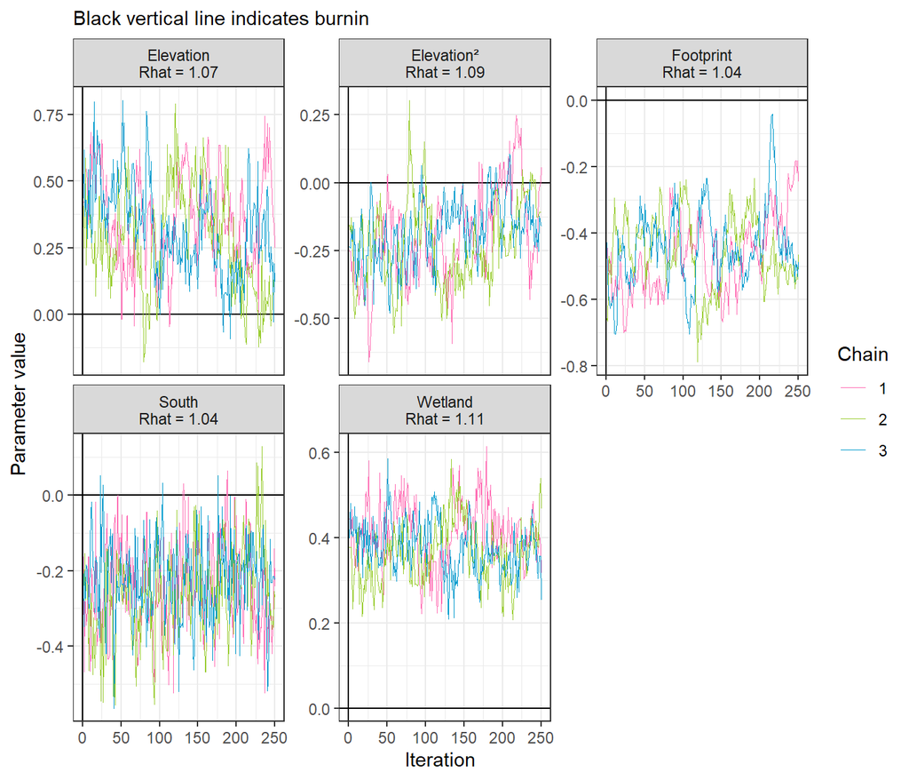

```r
# Process (beta) coefficients
plot_chains(samples,
            data = data,
            cov.labs = cov.labs,
            plot = "B",
            cutoff = 0)$plot
```

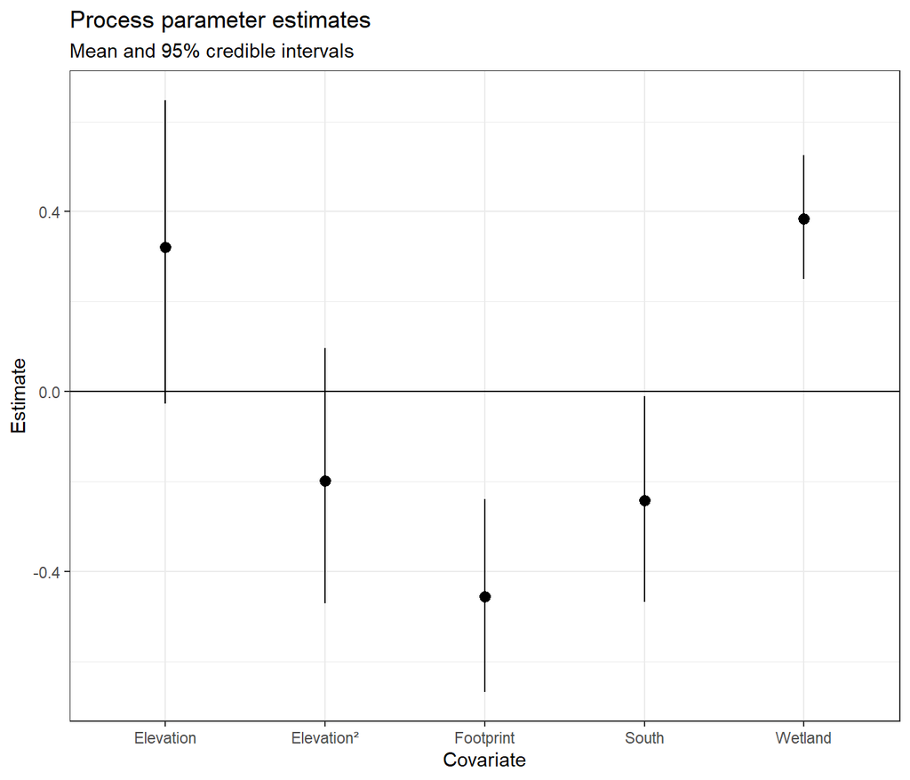

```r
plot_pars(out = out$process.coef,
          cov.labs = cov.labs)$plot
```

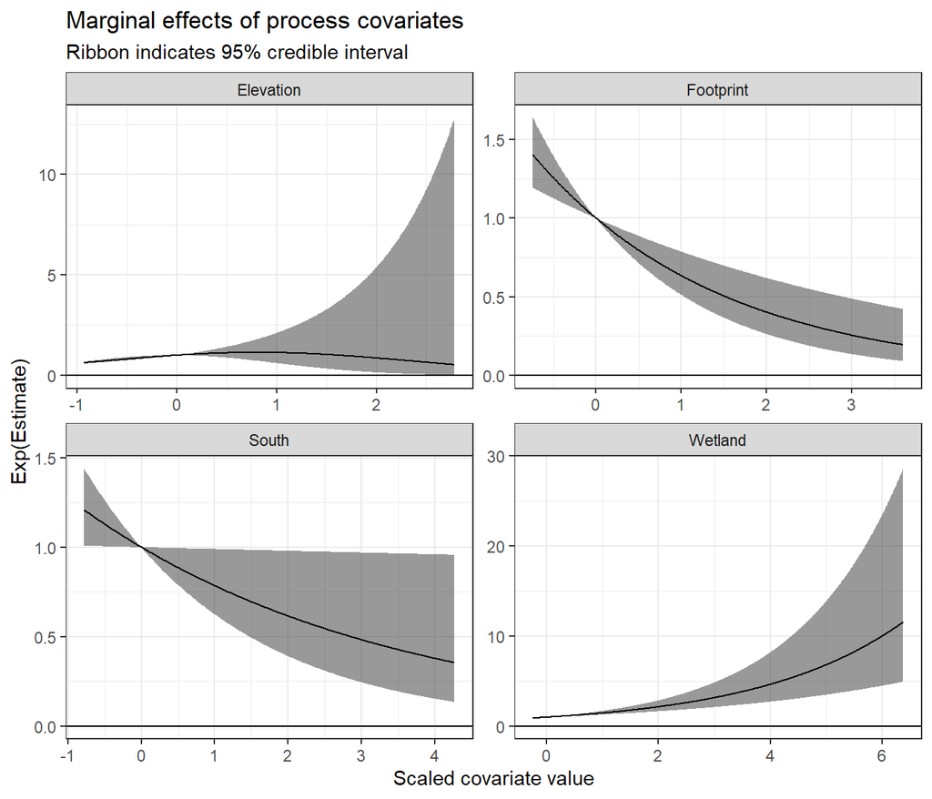

```r
plot_effects(data = data,
             out = out,
             cov.labs = cov.labs,
             unscale_covar = TRUE)$plot
```

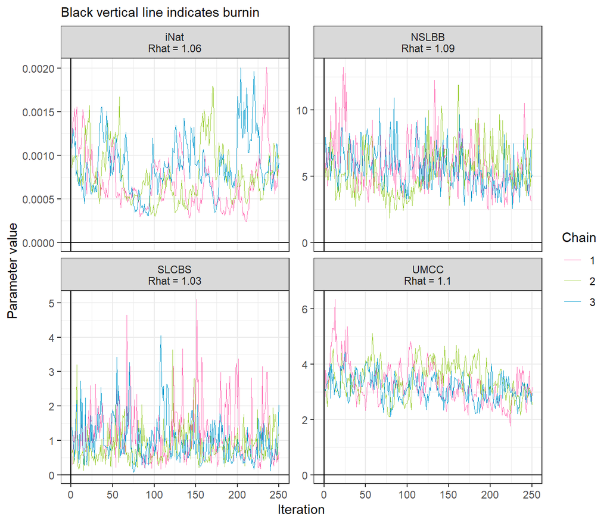

```r
# Dataset intercepts (alpha)
plot_chains(samples,
            data = data,
            constants = constants,
            cov.labs = cov.labs,
            plot = "alpha",
            cutoff = 0)$plot
```

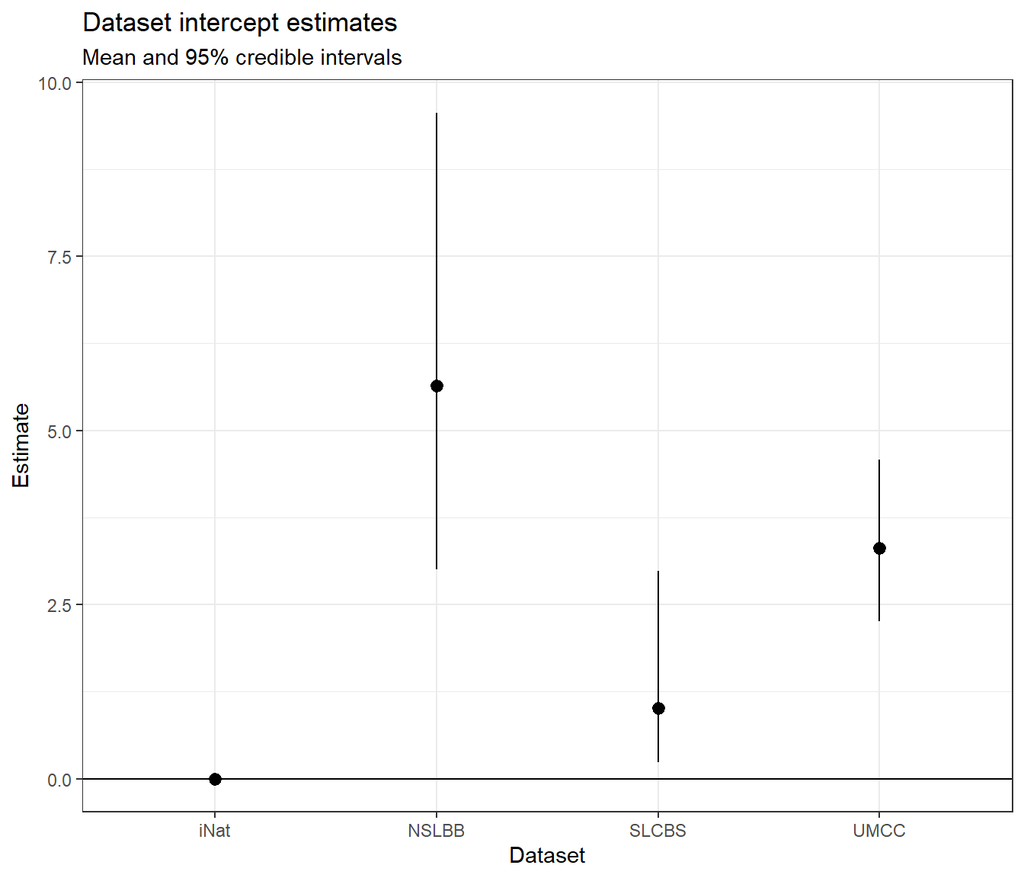

```r
plot_pars(out = out$alpha,
          cov.labs = cov.labs)$plot
```

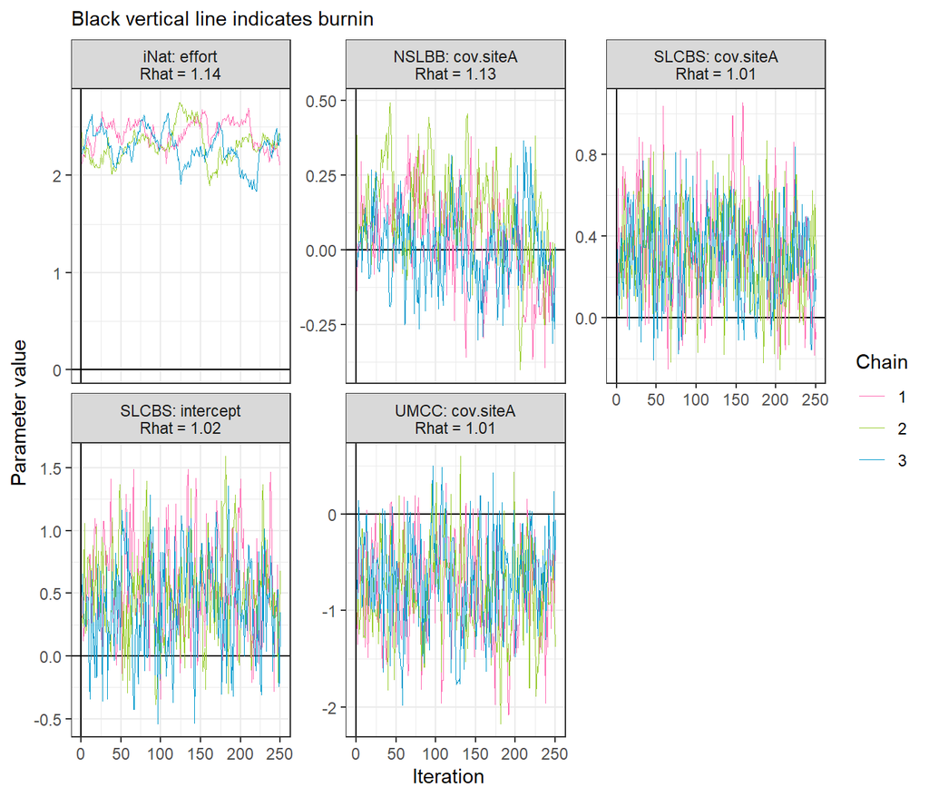

```r
# Observation coefficients
plot_chains(samples,
            data = data,
            constants = constants,
            cov.labs = cov.labs,
            plot = "observation",
            cutoff = 0)$plot
```

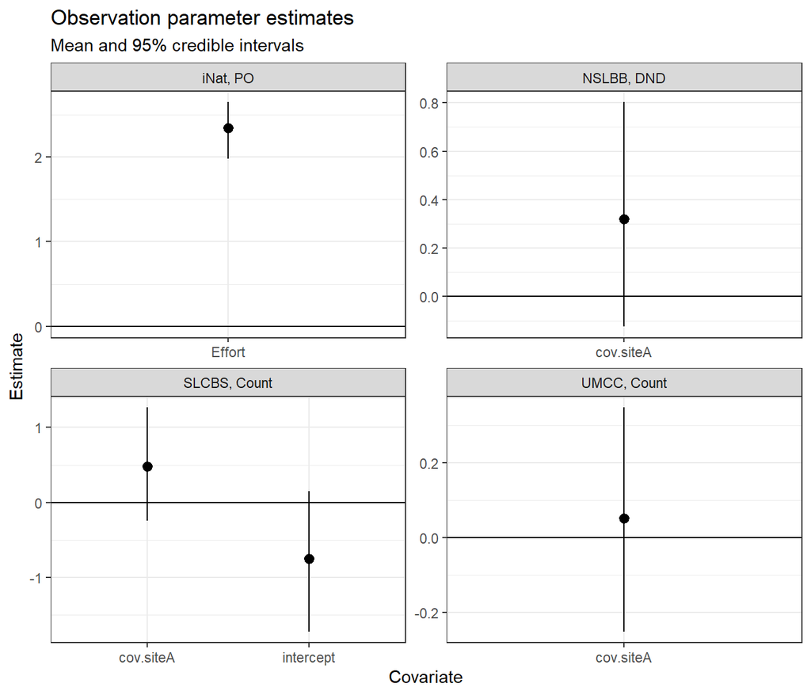

```r
plot_pars(out = out$obs.coef,
          cov.labs = cov.labs)$plot
```

> **Checkpoint.** Look for well-mixed, overlapping chains (“fuzzy caterpillars”). Poor mixing means you need more iterations. Sometimes, poor mixing can also be a sign of insufficient data.

## 7.2 Map predictions

```
#> Using real map features
```

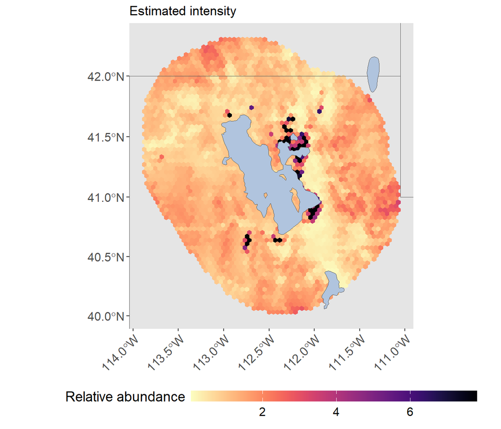

```r
# Relative abundance (intensity)
map_species_data(title = "Estimated intensity",
                 region = region, out = out, sim = TRUE,
                 plot = "lambda", plot.range = FALSE, plot.region = TRUE)$plot
```

```
#> Using real map features
```

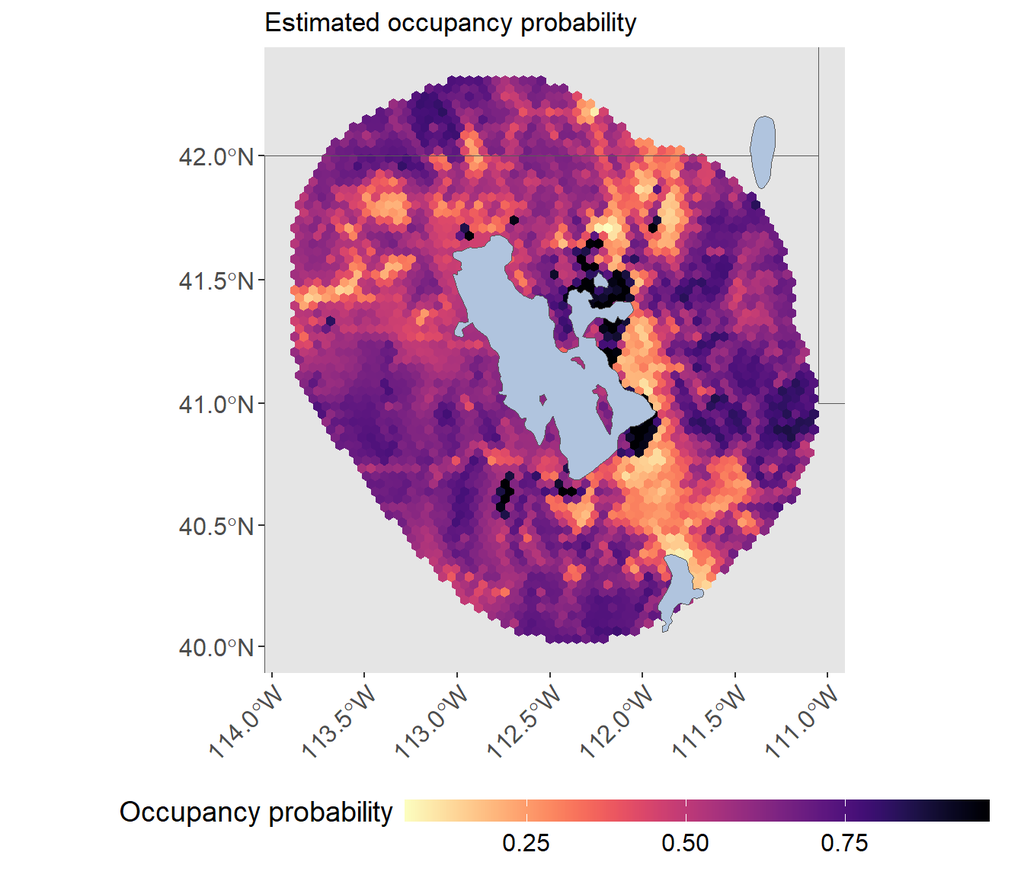

```r
# Occupancy probability
map_species_data(title = "Estimated occupancy probability",
                 region = region, out = out, sim = TRUE,
                 plot = "psi", plot.range = FALSE, plot.region = TRUE)$plot
```

# 8 Comparing estimates to truth

Because this is simulated, we know the true parameters. Use `sim_compare()` to evaluate recovery. Most `flexiSDM` plotting functions return a list with `$plot` (a ggplot object) and `$data` (the underlying data frame).

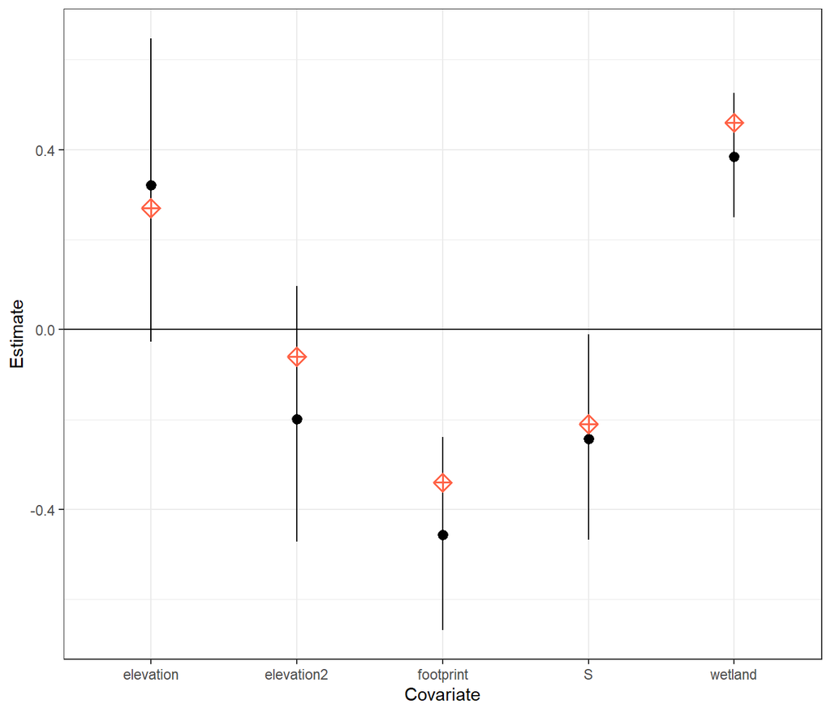

```r
names(datalist) <- names(species.data$obs)

tmp <- sim_compare(out, true = true, plot = "process")
tmp$plot
```

```r
tmp$data
```

| covariate | true | block.out | mean | lo | hi | lotail | hitail | unc.range | unc.rel | rhat | ESS |
| --- | --- | --- | --- | --- | --- | --- | --- | --- | --- | --- | --- |
| wetland | 0.46 | none | 0.3841470 | 0.25002314 | 0.52594935 | 0.1626667 | 0.1493333 | 0.2759262 | 0.7182829 | 1.109331 | 40.61931 |
| footprint | -0.34 | none | -0.4563112 | -0.66796974 | -0.23954545 | 0.1680000 | 0.1520000 | 0.4284243 | -0.9388862 | 1.039568 | 42.83025 |
| elevation | 0.27 | none | 0.3211606 | -0.02700634 | 0.64752493 | 0.1600000 | 0.1760000 | 0.6745313 | 2.1002930 | 1.069550 | 44.26986 |
| elevation2 | -0.06 | none | -0.1984253 | -0.47157197 | 0.09679411 | 0.1680000 | 0.1613333 | 0.5683661 | -2.8643834 | 1.090190 | 52.09721 |
| S | -0.21 | none | -0.2425317 | -0.46781406 | -0.01006350 | 0.1493333 | 0.1600000 | 0.4577506 | -1.8873847 | 1.035869 | 283.56913 |

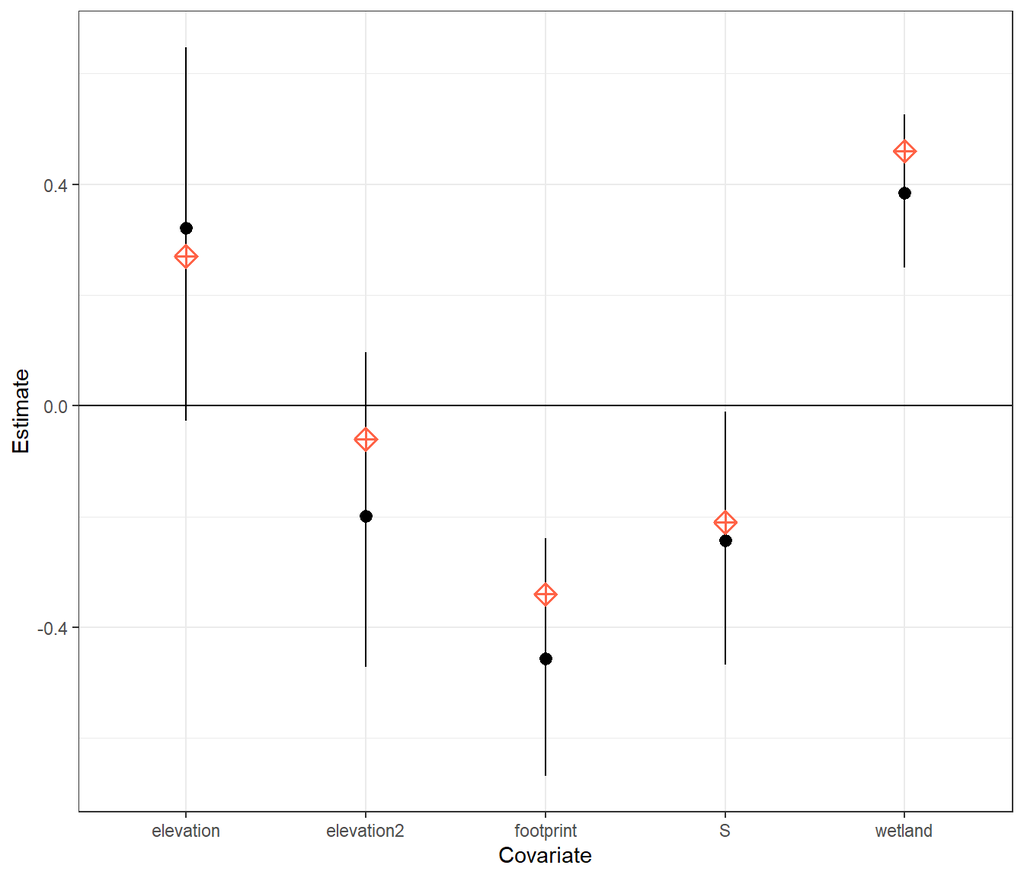

```r
sim_compare(out, true = true, plot = "process")$plot  # process coefficients
```

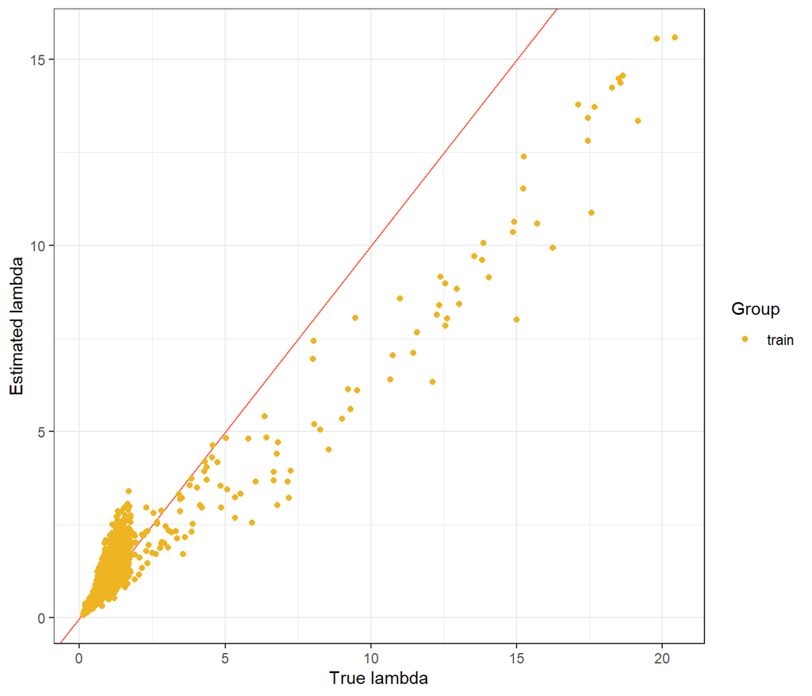

```r
sim_compare(out, true = true, plot = "lambda")$plot   # intensity
```

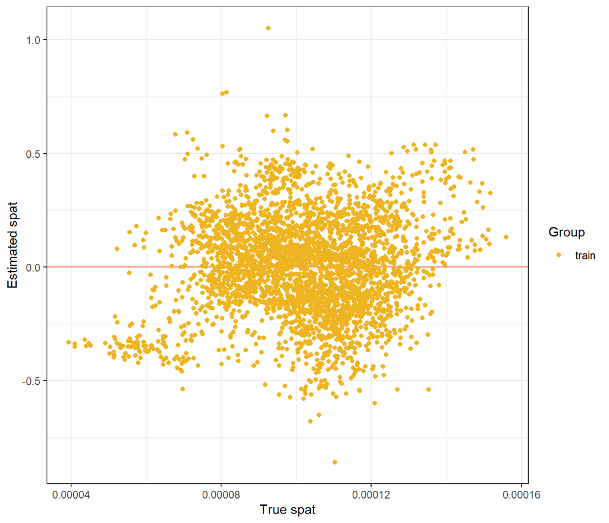

```r
sim_compare(out, true = true, plot = "spat")$plot     # spatial effect
```

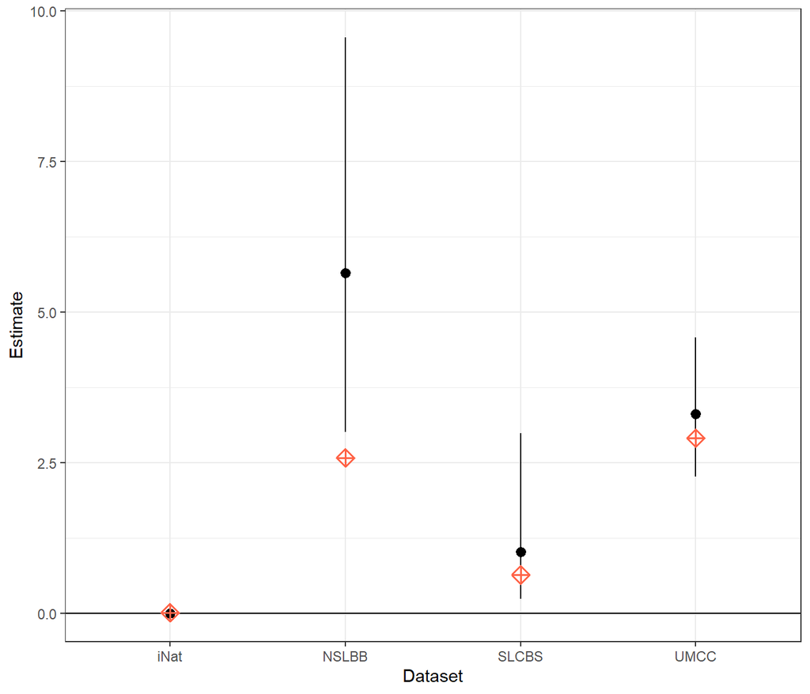

```r
sim_compare(out, true = datalist, plot = "alpha")$plot  # intercepts
```

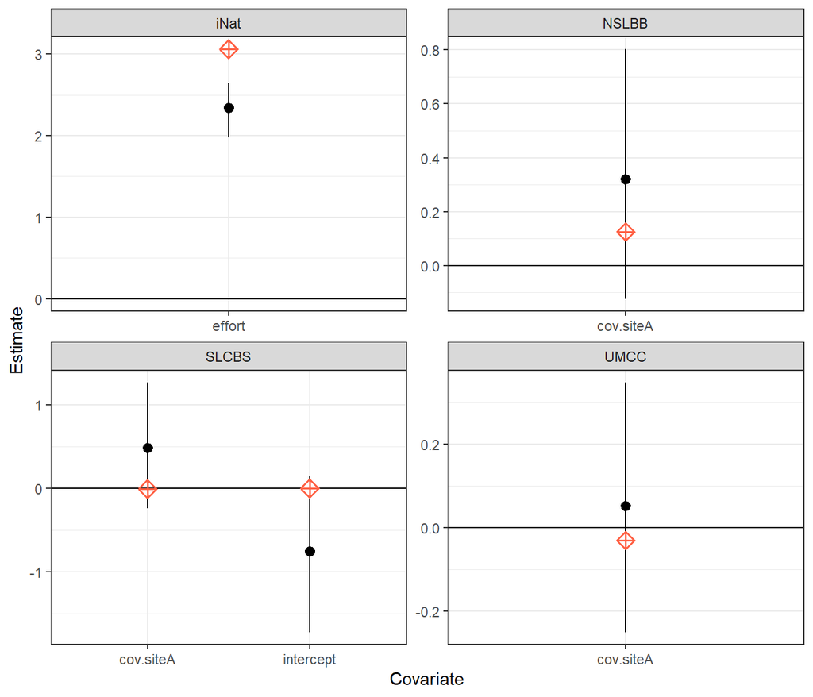

```r
sim_compare(out, true = datalist, plot = "obs")$plot    # observation params
```

> **Discussion.** How close are the estimates to the “truth”? Which parameters are recovered well, and which are uncertain?

# 9 Why we need data integration

The central motivation for iSDMs is that **combining datasets generally beats using any one alone**. We demonstrate this by comparing the integrated model against models fit to each dataset separately. Pre-computed single-dataset outputs are provided.

```r
load("TWS2026/data/model-outputs.RData", verbose = TRUE)
```

```
#> Loading objects:
#>   all.proc
#>   all.alph
#>   all.lamb
#>   all.obs
#>   all.spat
```

## 9.1 Compare process parameters

Look for the `"all"` model producing estimates **closer to truth** with **tighter intervals** than the single-dataset models.

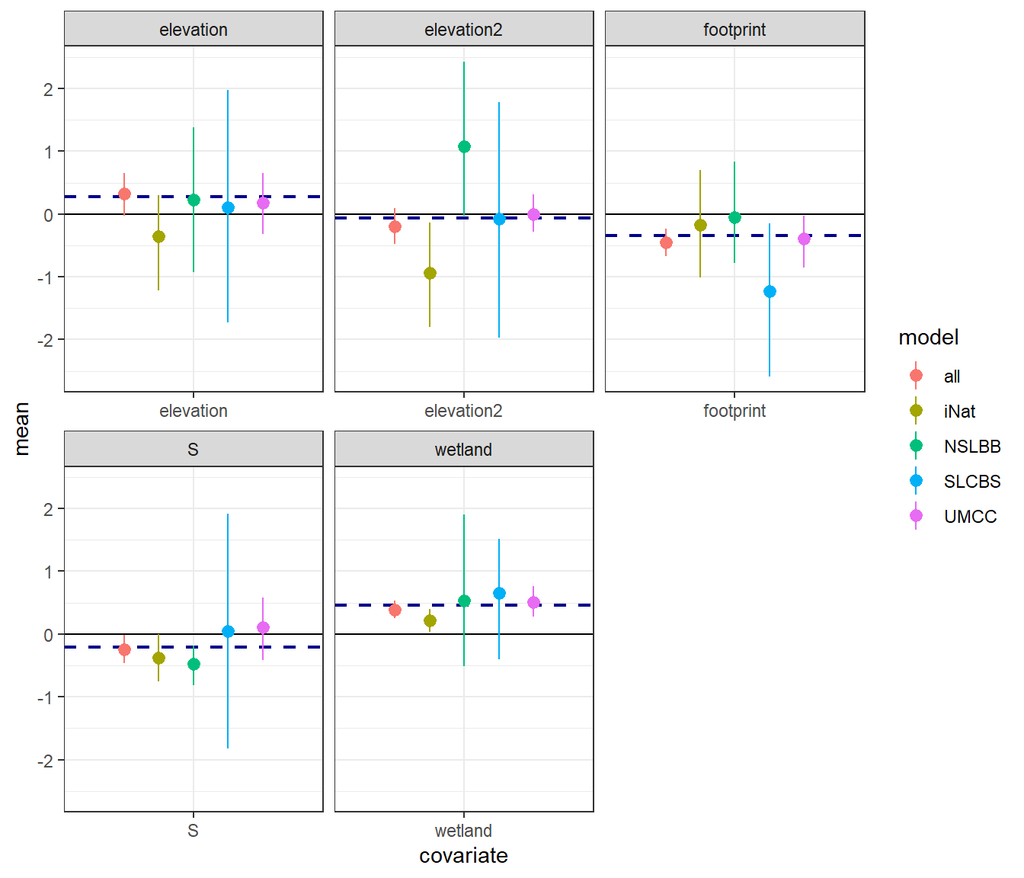

```r
proc <- sim_compare(out,
                    true = true,
                    plot = "process")$dat %>%
        mutate(model = "all")  # label the integrated model

all.proc <- bind_rows(all.proc, proc)   # add to single-dataset results

ggplot(all.proc) +
  geom_hline(yintercept = 0) +
  geom_hline(aes(yintercept = true), color = "darkblue",
             linetype = "dashed", linewidth = 0.75) +
  geom_pointrange(aes(x = covariate, y = mean, ymin = lo, ymax = hi,
                      color = model, group = model),
                  position = position_dodge(width = 0.8)) +
  facet_wrap(~ covariate, scales = "free_x") +
  theme_bw()
```

## 9.2 Compare intensity estimates

The best predictions fall closest to the 1-to-1 line.

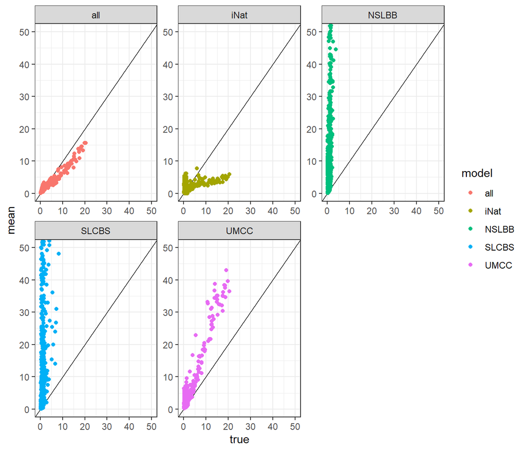

```r
lamb <- sim_compare(out, true = true, plot = "lambda")$dat %>%
          mutate(model = "all")
all.lamb <- bind_rows(all.lamb, lamb)

# Estimated vs. true
ggplot(all.lamb) +
  geom_abline(intercept = 0, slope = 1) +
  geom_point(aes(x = true, y = mean, color = model)) +
  facet_wrap(~ model, scales = "free") +
  coord_cartesian(xlim = c(0, 50), ylim = c(0, 50)) +
  theme_bw()
```